# Henry J. Kelley 1960 · 역전파의 수학적 기원 | 편집가능 강의

**KELLEY 1960** · 최적 비행경로와 역전파 1 / 25

01 / 연구자와 문제의 출발

KELLEY / 196001

## Henry Joseph Kelley

인공지능 연구자가 아닌 항공우주공학자가 1960년에 역전파의 수학적 선구 원리를 다듬었다.

1926–1988 Hank Kelley

HENRY J.  
*KELLEY*

항공우주공학최적제어비행경로 최적화

왜 이 논문을 썼나? — 논문 서론에서 확인

현실적인 비행조건에서는 기존 수학적 해법이 출발점과 도착점의 조건을 동시에 맞추기 어려웠다. Kelley는 기울기를 반복 계산해 비행경로를 실제로 개선하는 수치적 방법을 찾았다.

원문 p.947 · 연구 배경에 근거한 해석, 개인적 심리 동기는 알 수 없음

전공 · 교육 · 주요 경력

1948

**New York University**

항공공학 학사(B.Ae.E.) · 1951년 석사(M.S.)

1958

**공학박사(Sc.D.)**

NYU 항공학 · 최적 비행경로 연구 논문

1948–63

**Grumman Aircraft**

연구원·연구부 부책임자 / 1960년 논문 당시 Systems Research Section Leader

1963

**Analytical Mechanics Associates 창립**

이후 NASA Apollo 임무계획 관련 기술 연구

1978–88

**Virginia Tech 교수**

항공우주·해양공학, Christopher C. Kraft Jr. 석좌

경력: Virginia Tech Special Collections / 1960 논문 표제·각주

출처: Virginia Tech 인명기록 / Kelley (1960), p.94701 / 00

02 / 오늘의 질문

KELLEY / 196002

## 우주선의 경로와 AI 학습은 무엇이 같을까?

목표를 정하고, 마지막 결과에서 앞선 선택의 영향도를 계산한다는 점이 같다.

1960 · 최적제어

Solar Sail의 방향을 언제, 얼마나 바꾸어야 더 빨리 화성 궤도에 도착할까?

현재 · 딥러닝

정답과 예측의 차이를 줄이려면 어느 가중치를 얼마나 수정해야 할까?

공통 원리: 결과의 변화량을 거꾸로 계산 → 더 나은 방향으로 입력·파라미터 수정

개념도는 교육용 재구성 · 두 분야의 목적함수와 제약은 서로 다름02 / 00

03 / 논문 읽기

KELLEY / 196003

## 1960년 논문: 실제로 무엇을 제안했나?

논문의 목표는 신경망 학습이 아니라 최적 비행경로를 반복적으로 찾는 계산법이었다.

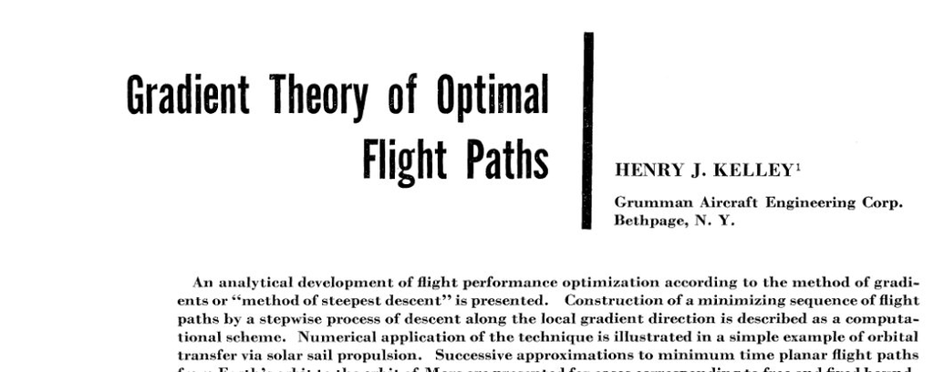

원문 p.947 · Gradient Theory of Optimal Flight Paths

연구 대상

우주선의 비행경로와 제어 입력(예: Solar Sail 각도)의 최적화

핵심 계산

종료 시점의 성능이 제어 입력 변화에 얼마나 민감한지를 계산하는 수반(Adjoint) 시스템

개선 방식

현재 경로의 기울기를 구하고, 비용이 감소하는 방향으로 반복 수정

ARS Journal 30(10), 947–954 · 발표 1960년 5월 / 게재 1960년 10월 · DOI 10.2514/8.5282

원문 p.947–949, DOI 10.2514/8.528203 / 00

04 / 기존 방법의 문제

KELLEY / 196004

## 왜 기존 계산법만으로는 어려웠을까?

출발 상태와 도착 상태를 한 번에 만족시키는 해를 직접 구하기 힘들었기 때문이다.

종점 조건까지 동시에 맞추려면 고차 미분방정식의 경계값 문제를 풀어야 한다.

기존의 간접법

Euler–Lagrange 방정식을 풀면서 시작 조건과 최종 조건을 동시에 충족하려고 한다. 현실적인 제약을 넣으면 계산이 복잡해진다.

Kelley의 직접적 접근

일단 가능한 경로에서 출발해, 성능이 좋아지는 방향을 계산하고 경로를 조금씩 수정한다.

핵심 전환: “정답 경로를 한 번에 풀기”보다 “현재 경로를 반복적으로 개선하기”

원문 p.947 서론 · 개념도(교육용)04 / 00

05 / 문제를 수학적으로 표현

KELLEY / 196005

## Kelley가 최적화한 것은 세 가지다

상태(state), 조작(control), 성능지표(objective)를 구분하면 수식이 간단해진다.

x(t)

상태 · state

우주선이 지금 어디에 있고 얼마나 빠르게 움직이는가?

위치, 속도, 질량 등

u(t)

제어 · control

우주선을 움직이기 위해 우리가 바꿀 수 있는 것은?

Solar Sail의 방향(원문에서는 y)

P

목표 · performance

어떤 결과를 가장 좋게 만들고 싶은가?

화성 궤도 도착까지 걸린 시간

dx/dt = f(x, u, t)

→

min P(x(tf), tf)

움직임의 법칙을 반드시 만족하면서 최종 비용을 최소화하는 제어 u(t)를 찾는다.

교육용 벡터 표기: 원문 Eq. (1)–(2)는 상태를 xₘ, 제어를 y로 표시한다.

원문 p.947, Eq. (1)–(2) · 기호 일부 강의용 변경05 / 00

06 / Solar Sail · 기본 구조

KELLEY / 196006

## Solar Sail이란? 우주선에 펼치는 거대한 반사막

바다의 돛이 바람을 받듯, Solar Sail은 태양빛의 운동량을 받아 우주선을 조금씩 가속한다.

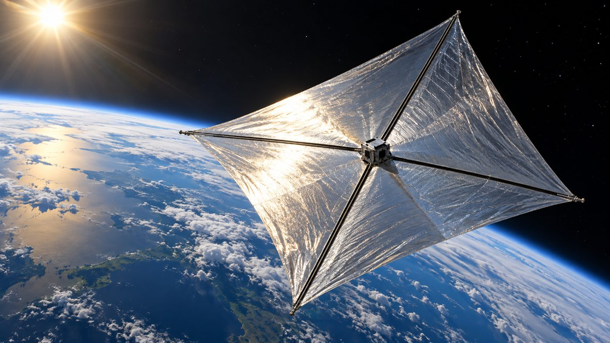

Solar Sail 우주선 모습 · 교육용 생성 이미지(실제 촬영 아님)

01 · WHAT

### 얇고 넓은 반사막

빛을 반사하는 막을 크게 펼쳐 아주 약한 힘을 모은다.

02 · HOW

### 광자(Photon)의 운동량

햇빛이 반사될 때 운동량을 전달해 우주선을 밀어준다.

03 · WHY

### 추진제 소비 없이 가속

매우 느리지만 태양빛을 받는 동안 추진력의 공급이 이어진다.

출처: NASA ACS3 미션 설명 · 그림은 학습용 재구성(실제 비행 사진이 아님)06 / 00

07 / Solar Sail · 추진 원리

KELLEY / 196007

## Solar Sail은 햇빛으로 어떻게 움직일까?

광자는 질량이 없어도 운동량을 가진다. 반사될 때 운동량이 바뀌면서 Solar Sail에 힘을 준다.

[figure not shown]

단순화 개념도: 광자 반사에 따른 평균 힘을 표시 · 실제 궤적과 기울기는 자세에 따라 달라짐

1

태양빛이 Solar Sail에 도달한다.

2

광자가 반사되며 운동량을 전달한다.

3

아주 작은 힘이 계속 쌓여 속도가 바뀐다.

주의: Solar Sail의 주된 추진 원인은 ‘태양풍’이 아니라 ‘태양광 복사압(Solar Radiation Pressure)’이다.

출처: NASA Solar Sail 기술 설명, NASA Solar Sails Use Sunlight (not the Solar Wind!)07 / 00

08 / Solar Sail · 추진계 비교

KELLEY / 196008

## 일반 로켓과 Solar Sail은 무엇이 다른가?

가장 큰 차이는 추진력을 만드는 방식이다. Solar Sail은 우주에서 추진제를 계속 분사하지 않는다.

### 일반 화학 로켓

**추진 원리**추진제를 연소·분사

**힘의 크기**순간적으로 매우 큼

**연료·작동**탑재 추진제가 줄어듦

**적합한 임무**발사, 급가속, 큰 궤도 변화

VS

### Solar Sail

**추진 원리**태양광 복사압 활용

**힘의 크기**아주 작고 지속적

**연료·작동**추진제 소비 없이 작동

**적합한 임무**장기 궤도 변경·우주항행

핵심: Solar Sail은 ‘로켓보다 센 엔진’이 아니라 ‘매우 작은 힘을 오래 사용하는 추진 방식’이다.

출처: NASA ACS3 / Solar Sail Propulsion · 일반적인 기술 특성 비교08 / 00

09 / Solar Sail · 장점과 한계

KELLEY / 196009

## Solar Sail이 좋은데 왜 모든 우주선이 쓰지 않을까?

연료 없이 움직인다는 장점만 보면 안 된다. 태양빛의 힘은 매우 약하고, 충분한 면적이 필요하다.

### Solar Sail의 장점

+

추진제 소모를 줄일 수 있다.

+

작은 힘을 장기간 누적할 수 있다.

+

장기 우주항행·특수 궤도 운용에 적합하다.

### 반드시 알아야 할 한계

−

추진력이 작아 큰 반사막이 필요하다.

−

태양에서 멀어질수록 힘이 약해진다.

−

지구에서 발사할 때는 로켓이 필요하다.

따라서 ‘언제, 어느 방향으로 Solar Sail을 기울여야 하는가’라는 최적화 문제가 중요해진다.

출처: NASA ACS3 / NASA Solar Sail 기술 설명 · 태양거리 영향은 정성적 개념도09 / 00

10 / Solar Sail · 각도와 궤적

KELLEY / 196010

## Solar Sail을 기울이면 우주선의 경로가 달라진다

돛이 햇빛을 받는 각도에 따라 반사되는 광자의 방향이 달라지고, 우주선이 받는 힘의 방향도 바뀐다.

CASE A

### 큰 반사압을 정면으로 받는 경우

CASE B

### 추진력의 방향을 바꾸는 경우

OPTIMIZATION

### 언제 돌리느냐에 따라 도착시간 변화

Kelley의 질문: “Solar Sail의 각도 θ(t)를 시간에 따라 어떻게 바꿔야 화성 궤도에 가장 빨리 도착할까?”

출처: Kelley (1960), Solar Sailing Example, p.950 · 반사압·궤적 방향은 설명용 개념도10 / 00

11 / Solar Sail · Kelley와 역전파

KELLEY / 196011

## 1960년 Kelley가 풀려던 문제는 무엇인가?

Solar Sail 자체를 발명하는 문제가 아니라, 최종 비행시간을 줄이는 최적 제어를 계산하는 문제였다.

입력 (Control)**Solar Sail 각도 θ(t)**

시간에 따라 기울일 방향

→

물리 상태 (State)**비행경로 x(t)**

위치·속도·궤도 변동

→

목표 (Objective)**비행시간 T**

화성 궤도까지 최소 시간

Backward · 수반방정식 (Adjoint Equation)

**1960년 Kelley**

Solar Sail 각도 → 궤적 → 도착시간 → 각도 수정

**오늘날 딥러닝**

가중치 → 예측 → 손실함수 → 가중치 수정

연결의 본질은 순방향으로 결과를 계산하고, 역방향으로 각 변수의 영향도를 계산해 다시 개선한다는 점이다.

원문: Kelley (1960), pp.947–950 · Forward / Backward 표현은 현대적 교육용 재구성11 / 00

12 / 논문의 실제 예제

KELLEY / 196012

## Solar Sail로 지구에서 화성 궤도까지

연료를 분사하기보다, 태양빛이 돛을 미는 힘의 방향을 조절하는 예제다.

조절할 것

시간에 따른 Solar Sail의 방향 θ(t)

바뀌는 것

태양광 압력의 추진력 성분 → 속도·궤적

최소화할 것

지구 궤도 출발부터 화성 궤도 도착까지 비행시간

“언제 어느 방향으로 돛을 돌려야 빠른가?”

원문 p.950–952, Fig. 1–4 · 회전/방향 묘사는 단순화12 / 00

13 / 경사하강법 직관

KELLEY / 196013

## 기울기를 따라 조금씩 내려가면 된다

산 위에서 가장 가파른 내리막을 찾듯, 현재보다 더 나은 경로를 반복해서 찾는다.

새 제어 = 기존 제어 −  
학습률 × 기울기

기울기는 “어느 쪽으로 얼마나 바꾸면 성능이 달라지는지” 알려준다.

한 번에 너무 많이 바꾸면 오히려 나빠지거나 최종 도착 조건을 어길 수 있다.

오늘날의 Gradient Descent와 같은 핵심 발상: 기울기의 반대 방향으로 갱신

원문 p.949–950, Eq. (32)–(33) · 포물선은 교육용 비유13 / 00

14 / 알고리즘 전체 흐름

KELLEY / 196014

## Kelley 방법을 4단계로 요약하면

비행을 시뮬레이션하고 → 최종 비용을 확인하고 → 역방향 민감도를 구하고 → 경로를 개선한다.

01

### 앞으로 계산

현재 돛 각도에 따라 실제 우주선 궤적을 계산

상태 방정식

02

### 결과 평가

화성 궤도까지 걸린 시간을 확인

목적함수 P

03

### 뒤로 영향 계산

최종 결과에서 거꾸로, 각 순간의 제어가 주는 영향을 계산

수반방정식 λ

04

### 조금 수정

비용이 줄어드는 방향으로 돛 조작 프로그램 변경

경사하강

순방향 Forward역방향 Backward업데이트 Update반복 Repeat

문제의 물리학은 다르지만, “순방향 계산 → 역방향 기울기 → 갱신” 구조가 유사하다.

원문 p.947–950, 특히 Eq. (7), (30), (33) · 현대 용어로 재구성14 / 00

15 / 논문의 핵심 수학

KELLEY / 196015

## 역방향 계산의 원형: Adjoint Equation

미래의 최종 결과가 현재 선택에 얼마나 민감한지 계산하는 보조방정식이다.

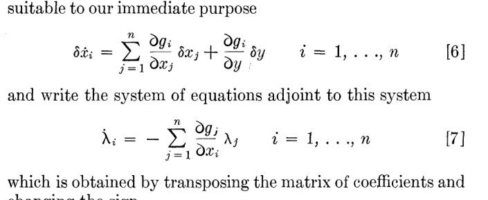

강의용 벡터 표기

dλ/dt = − (∂f/∂x)ᵀ λ

종료 시점의 정보 → 과거 방향 계산

λ(람다)의 의미

최종 비용을 줄이려면 현재 상태 x가 얼마나 중요한지를 나타내는 민감도

왜 뒤로 계산하나?

최종 성능에서 출발해 과거 상태·제어가 끼친 영향을 효율적으로 구할 수 있기 때문

원문 Eq. (7)은 adjoint ODE 자체를 제시하며, 현대 신경망의 층별 Chain Rule 구현을 그대로 제시한 것은 아니다.

원문 p.948, Eq. (6)–(9) · 단순화 수식(종말비용 기준)15 / 00

16 / 역전파의 수학적 연결

KELLEY / 196016

## Forward와 Backward의 역할을 분리하자

현재 상태는 시간을 따라 앞으로, 최종 손실의 영향도는 과거로 계산한다.

FORWARD · 순방향

x₀

x₁

x₂

x₃

P

제어 u를 적용하면 상태 x가 차례로 바뀌고 마지막에 비용 P가 결정된다.

BACKWARD · 역방향

λ₀

λ₁

λ₂

λ₃

최종 비용

마지막 비용이 각 단계의 상태·제어에 얼마나 영향을 받는지 역순으로 계산한다.

상태 변화

**dx/dt = f(x,u,t)**

수반 변수

**dλ/dt = −fₓᵀλ**

제어의 기울기

**∂P/∂u = fᵤᵀλ**

위 식은 종말비용 P(x(tf))와 고정된 경계·제약이 단순한 경우의 교육용 표현이다. 원문은 종말시간, 자유·고정 경계조건 및 보정 항을 함께 다룬다.

원문 p.947–949, Eq. (1)–(2), (7), (26)–(33) · 교육용 단순화16 / 00

17 / 실제 논문 결과

KELLEY / 196017

## 정말로 비행시간이 줄어들었을까?

원문은 Solar Sail의 제어를 수정할수록 최적 도착시간에 접근하는 모습을 그래프로 보여준다.

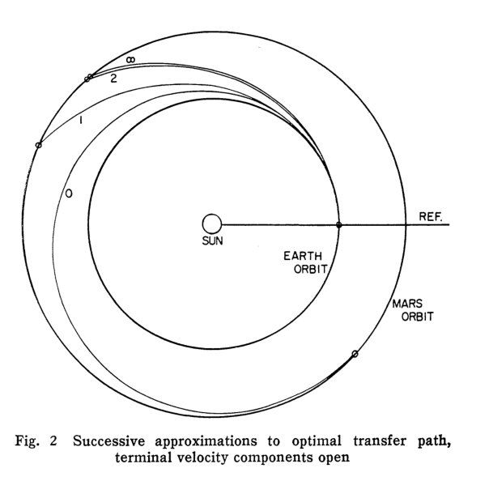

Fig. 2 · 갱신마다 달라지는 지구–화성 궤적 (p.952)

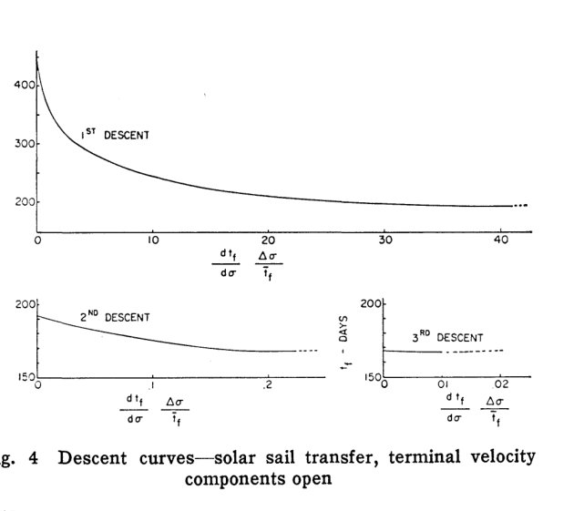

Fig. 4 · 갱신 과정의 비행시간 감소 (p.952)

첫 개선에서 절반 이상 단축

종단 속도를 자유롭게 둔 사례에서 첫 경사하강 단계만으로 초기 비행시간이 절반 이상 줄었고, 약 세 차례의 하강으로 실용적인 최소 비행시간에 가까워졌다고 저자가 설명했다.

원문 p.951–952, Fig. 2–4 및 결과 본문 · 그림은 첨부 원문에서 발췌17 / 00

18 / 현실적인 제약

KELLEY / 196018

## 목적함수를 낮추는 것만으로 충분할까?

빨리 도착하더라도 화성 궤도에서 필요한 속도 조건을 만족하지 못하면 실패다.

Case A · Free boundary

### 도착 속도는 자유롭게

화성 궤도에 도착하는 시간 자체를 줄이는 데 집중한다.

조건이 비교적 단순함

Case B · Matched boundary

### 도착 속도도 일치시켜야

도착할 때 반경방향·접선방향 속도를 목표 행성과 맞추는 제한이 추가된다.

더 어려운 최적화

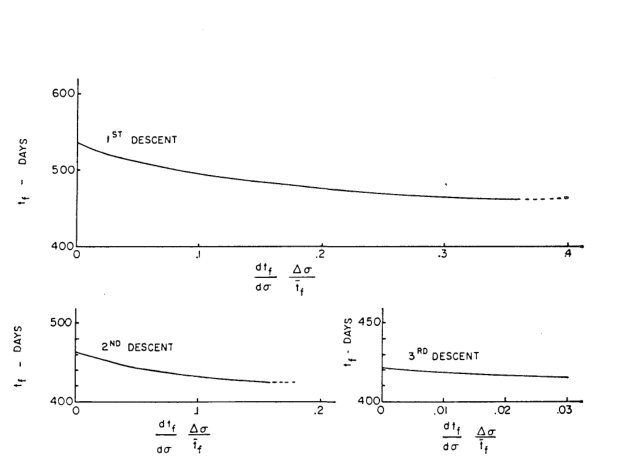

Fig. 6 · 도착 속도 제약을 둔 경우의 비행시간 개선 (p.952)

최적화에서 “비용 최소화”와 “필수 조건 준수”는 서로 다른 문제이며 동시에 관리해야 한다.

원문 p.950–953, Fig. 5–8 · 제약 조건의 의미를 강의용으로 요약18 / 00

19 / 신경망과 연결

KELLEY / 196019

## 비행경로를 신경망으로 바꾸어 보면

시간 단계별 제어가 신경망의 가중치로, 비행시간이 예측 오차로 바뀐다.

1960 Kelley · 최적 비행경로현대 딥러닝 · 신경망 학습

시간에 따라 변하는 상태 x(t)층을 지나며 바뀌는 활성값 a¹, a² …

돛 각도·조향 명령 u(t)가중치 W, 편향 b

최종 성능 P (비행시간 등)손실 L (정답과 예측의 차이)

수반변수 λ를 역방향 계산오차 기울기 ∂L/∂W를 역방향 계산

기울기를 따라 제어 프로그램 수정경사하강법으로 가중치 갱신

정확히 구분할 점

Kelley는 비행 궤적 최적화에 필요한 연속시간 수반 방법을 연구했다. 오늘날 신경망의 다층 자동미분 알고리즘을 직접 발표한 것은 아니다.

Kelley (1960) / Linnainmaa (1970) / 현대 신경망 해석을 비교한 교육용 표19 / 00

20 / 손으로 계산해 보기

KELLEY / 196020

## 역전파 예제: 숫자 2개만 고쳐도 학습된다

선형 신경망 y = (x × w₁) × w₂ 에서 최종 오차를 이용해 각 가중치의 기울기를 구한다.

정답 t = 20

초기 예측 ŷ = 24

손실 L = (24 − 20)² / 2 = 8

Chain Rule · 연쇄법칙

∂L/∂w₂ = 4 × 6 = **24**

∂L/∂w₁ = 4 × 4 × 2 = **32**

w₁ ← 3 − 0.01 × 32 = 2.68

w₂ ← 4 − 0.01 × 24 = 3.76

새 예측 20.1536 → 새 손실 약 0.0118

이 계산은 현대적인 이산형 신경망을 설명하기 위한 교육용 예제이며, Kelley 원문의 실험 데이터 또는 수식 수치가 아니다.

교육용 계산 예시 · 학습률 0.01, 동시 갱신, 손실 L=½(ŷ−t)²20 / 00

21 / 직접 조작하는 미니 실험

KELLEY / 196021

## 학습률을 바꾸면 얼마나 빨리 수렴할까?

이 강의용 실험은 L(w) = (w − 3)² 의 최소값을 찾는 단순 경사하강법이다.

INTERACTIVE · 이 슬라이드에서 실제 실행

학습률 η **0.25**

현재 w **−1.00**

현재 손실 **16.0000**

반복 횟수 **0**

학습률이 너무 크면 최솟값을 지나치며 진동하거나 발산한다. 논문에서도 지나치게 큰 변화폭은 경계조건 위반을 초래할 수 있다고 주의했다.

교육용 함수 L(w)=(w−3)² · 논문과 개념 비교: p.950 단계폭 선택21 / 00

22 / 역사적 사실 확인

KELLEY / 196022

## 누가 역전파를 발명했을까?

‘선구적 수학 원리’와 ‘신경망 학습 알고리즘’은 서로 다른 기여다.

1960

### Henry J. Kelley

최적제어의 수반방정식과 기울기 하강법을 비행경로 문제에 적용

선구 연구

1970

### Seppo Linnainmaa

현대적 역방향 자동미분(Reverse-mode AD)의 효율적인 계산 절차

자동미분

1974

### Paul Werbos

박사학위 연구에서 역전파와 학습을 연결하는 접근 제시

학습 적용

1986

### Rumelhart · Hinton · Williams

다층 신경망의 오차 역전파 학습을 널리 알리고 실증

대중화

역전파의 ‘최초 발명자’를 단 한 명으로 확정하기보다, 연속 수반법·역방향 자동미분·신경망 학습에서의 기여를 구분하는 것이 정확하다.

역사적 구분: Schmidhuber, Who Invented Backpropagation?; Kelley (1960)22 / 00

23 / 반도체 공정의 시사점

KELLEY / 196023

## 반도체 공정 최적화에도 같은 사고가 필요하다

제어변수 변경 → 공정 상태 변화 → 최종 품질 평가 → 더 나은 조건 탐색

INPUT

### 설정값 u

온도, 압력, RF 전력, 가스 유량

→

SYSTEM

### 공정 상태 x

두께, 식각률, 플라즈마 상태

→

OUTPUT

### 품질·수율 P

불량률, 균일도, 성능 저하

교수 강의에서 강조할 핵심 차이

물리 모델이 미분 가능하고 제어 입력이 실제 원인일 때는 수반·기울기 기반 최적화를 고려할 수 있다. 반면 관측 데이터로 학습한 모델의 기울기는 인과관계나 안전한 공정 변경을 자동 보장하지 않는다.

무엇을 바꿀 수 있는가?

최종 품질은 무엇으로 측정하나?

안전·수율 제약은 무엇인가?

반도체 사례는 논문 직접 내용이 아닌 공학적 확장 예시23 / 00

24 / 강의 결론

KELLEY / 196024

## 학생이 기억해야 할 것은 단 세 가지

역전파의 본질은 “실패 이유를 과거 선택까지 되짚어 개선하는 계산”이다.

01

### 문제에서 출발했다

1960년의 질문은 신경망이 아니라 비행경로를 어떻게 최적화할 것인가였다.

02

### 결과에서 거꾸로 계산한다

수반방정식은 최종 성능에 대한 과거 상태·조작의 민감도를 효율적으로 구한다.

03

### 계산한 뒤 반드시 검증한다

기울기를 이용해 개선할 수 있지만 경계조건·제약·수렴성 확인이 필수다.

AI를 잘 활용하는 엔지니어는 모델 이름보다 “목표, 기울기, 제약, 검증”을 먼저 생각한다.

Kelley (1960) 연구의 교육적 해석24 / 00

25 / 출처와 원문

KELLEY / 196025

수업 시간에는 947쪽 서론 → 948쪽 Eq. (7) → 952쪽 Fig. 4 순서로 읽으면 충분하다.

01

### Henry J. Kelley (1960)

Gradient Theory of Optimal Flight Paths · ARS Journal 30(10), 947–954 · 논문 전문(8쪽)

[원문 PDF 열기](https://gwern.net/doc/statistics/decision/1960-kelley.pdf)[DOI 10.2514/8.5282](https://doi.org/10.2514/8.5282)

02

### Virginia Tech Special Collections

Henry J. Kelley (1926–1988) · 학위, Grumman 연구, NASA 관련 경력, 교수 이력

[인명기록 보기](https://aspace.lib.vt.edu/agents/people/185)

03

### Jürgen Schmidhuber · 역사 정리

Who Invented Backpropagation? · Kelley, Linnainmaa, Werbos 등의 역사적 기여를 구분

[역전파 역사 글 보기](https://people.idsia.ch/~juergen/who-invented-backpropagation.html)

원문에서 꼭 볼 곳: p.947 문제 배경 → p.948 수반방정식 [7] → p.949 단계적 경사하강 [33] → p.952 실험 결과 Fig. 4

논문 원문 + 대학 아카이브 + 역사 검토 자료 · 모든 외부 링크는 인터넷 연결 필요25 / 00